# The Synthetic Causal Framework

#### 10.5.3.2 Model Parameters

Table 10.23: 13-Number Summary of Difference in Welfare Support across Manipulation Conditions

| Percentile | Posterior | Likelihood |
| --- | --- | --- |
| 0% | 0.572 | 0.571 |
| 0.1% | 0.579 | 0.580 |
| 1% | 0.586 | 0.587 |
| 5% | 0.592 | 0.592 |
| 10% | 0.595 | 0.596 |
| 25% | 0.601 | 0.601 |
| 50% | 0.607 | 0.608 |
| 75% | 0.613 | 0.613 |
| 90% | 0.619 | 0.619 |
| 95% | 0.622 | 0.622 |
| 99% | 0.628 | 0.628 |
| 99.9% | 0.635 | 0.635 |
| 100% | 0.643 | 0.648 |

**NOTE**: Posterior and (maximum) likelihood distributions of the estimated normalized coefficient parameter ($\hat{\beta_G}$), estimated with NUTS MCMC (Hoffman and Gelman 2014) and REML-based non-parametric bootstrap (Efron and Tibshirani 1994), respectively. Posterior/likelihood samples = 40,005. Mean = .607 and .607, respectively. IQR = .012 and .012, respectively. Skewness = .009 and -.008, respectively. Kurtosis = -.017 and .008, respectively. Results derived from synthetic data generated by OpenAI’s (2024a) gpt-4o-mini using vignettes and questions created by Aarøe and Petersen (2014) and Petersen et al. (2012), as well as data by the IPUMS (Ruggles et al. 2024) and ANES (2021).

Figure 10.27: Difference in Welfare Support across Manipulation Conditions

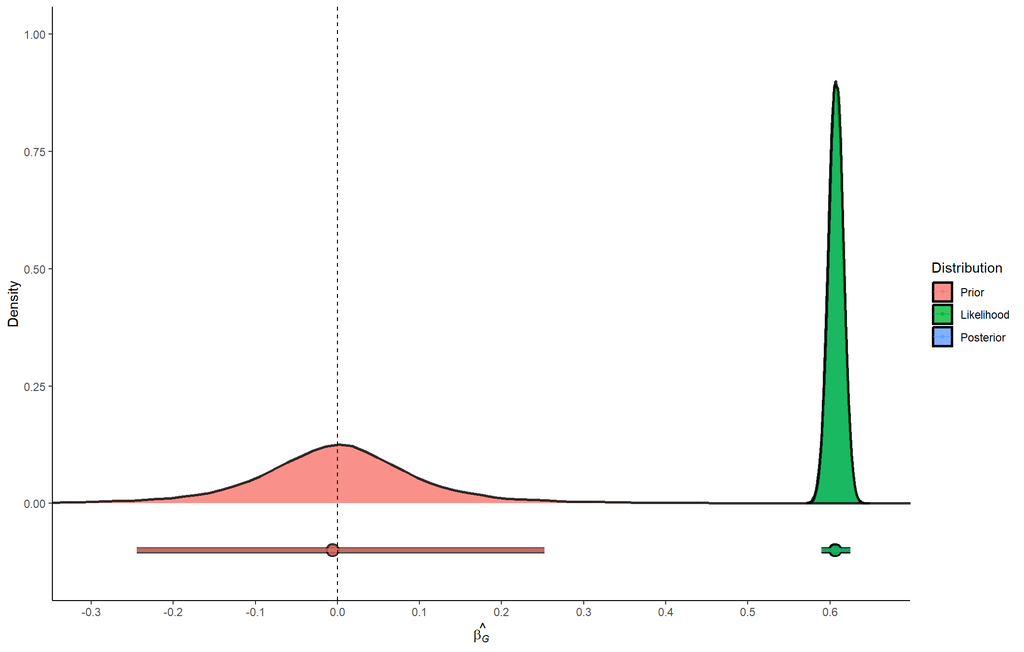

**NOTE**: Posterior, (maximum) likelihood, and prior distributions of the estimated normalized coefficient parameter ($\hat{\beta_G}$). Posterior/likelihood/prior samples = 40,005; prior is not necessarily correctly visualized due to finite samples. The posterior distribution is not easily visible due to being obscured by the likelihood distribution. The dashed black line indicates a difference in welfare support of zero. The geometric below the distributions indicate the posterior mode (circle) and the 95% HDCI (thick bar). Results derived from synthetic data generated by OpenAI’s (2024a) gpt-4o-mini using vignettes and questions created by Aarøe and Petersen (2014) and Petersen et al. (2012), as well as data by the IPUMS (Ruggles et al. 2024) and ANES (2021).

Table 10.24: 13-Number Summary of Welfare Support when presented with a ‘Lazy’ Welfare Recipient

| Percentile | Posterior | Likelihood |
| --- | --- | --- |
| 0% | 0.310 | 0.308 |
| 0.1% | 0.317 | 0.317 |
| 1% | 0.324 | 0.323 |
| 5% | 0.329 | 0.328 |
| 10% | 0.331 | 0.331 |
| 25% | 0.336 | 0.336 |
| 50% | 0.341 | 0.342 |
| 75% | 0.346 | 0.347 |
| 90% | 0.351 | 0.352 |
| 95% | 0.354 | 0.355 |
| 99% | 0.359 | 0.361 |
| 99.9% | 0.364 | 0.367 |
| 100% | 0.375 | 0.378 |

**NOTE**: Posterior and (maximum) likelihood distributions of the estimated normalized intercept parameter ($\hat{\mu_\alpha}$), estimated with NUTS MCMC (Hoffman and Gelman 2014) and REML-based non-parametric bootstrap (Efron and Tibshirani 1994), respectively. Posterior/likelihood samples = 40,005. Mean = .341 and .342, respectively. IQR = .010 and .011, respectively. Skewness = .004 and .024, respectively. Kurtosis = -.028 and -.010, respectively. Results derived from synthetic data generated by OpenAI’s (2024a) gpt-4o-mini using vignettes and questions created by Aarøe and Petersen (2014) and Petersen et al. (2012), as well as data by the IPUMS (Ruggles et al. 2024) and ANES (2021).

Figure 10.28: Welfare Support when presented with a ‘Lazy’ Welfare Recipient

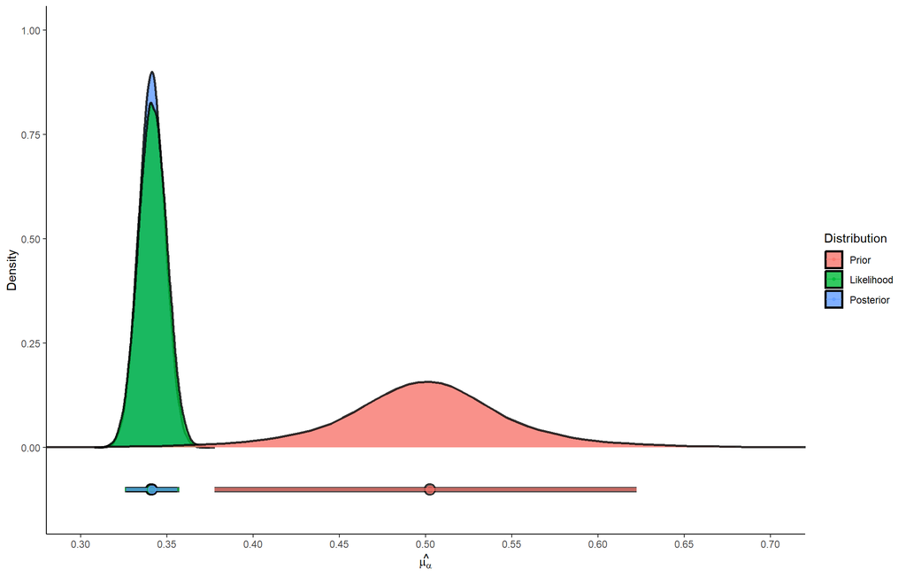

**NOTE**: Posterior, (maximum) likelihood, and prior distributions of the estimated normalized intercept mean parameter ($\hat{\mu_\alpha}$). Posterior/likelihood/prior samples = 40,005; prior is not necessarily correctly visualized due to finite samples. The geometric below the distributions indicate the posterior mode (circle) and the 95% HDCI (thick bar). Results derived from synthetic data generated by OpenAI’s (2024a) gpt-4o-mini using vignettes and questions created by Aarøe and Petersen (2014) and Petersen et al. (2012), as well as data by the IPUMS (Ruggles et al. 2024) and ANES (2021).

Table 10.25: 13-Number Summary of Welfare Support Variability when presented with a ‘Lazy’ Welfare Recipient

| Percentile | Posterior | Likelihood |
| --- | --- | --- |
| 0% | 0.094 | 0.147 |
| 0.1% | 0.102 | 0.152 |
| 1% | 0.108 | 0.154 |
| 5% | 0.113 | 0.157 |
| 10% | 0.116 | 0.158 |
| 25% | 0.121 | 0.160 |
| 50% | 0.126 | 0.163 |
| 75% | 0.131 | 0.165 |
| 90% | 0.136 | 0.167 |
| 95% | 0.138 | 0.169 |
| 99% | 0.143 | 0.171 |
| 99.9% | 0.148 | 0.174 |
| 100% | 0.156 | 0.176 |

**NOTE**: Posterior and (maximum) likelihood distributions of the estimated normalized intercept dispersion parameter ($\hat{\sigma_\alpha}$), estimated with NUTS MCMC (Hoffman and Gelman 2014) and REML-based non-parametric bootstrap (Efron and Tibshirani 1994), respectively. Posterior/likelihood samples = 40,005. Mean = .126 and .163, respectively. IQR = .010 and .005, respectively. Skewness = -.075 and -.075, respectively. Kurtosis = .023 and -.013, respectively. Results derived from synthetic data generated by OpenAI’s (2024a) gpt-4o-mini using vignettes and questions created by Aarøe and Petersen (2014) and Petersen et al. (2012), as well as data by the IPUMS (Ruggles et al. 2024) and ANES (2021).

Figure 10.29: Welfare Support Variability when presented with a ‘Lazy’ Welfare Recipient

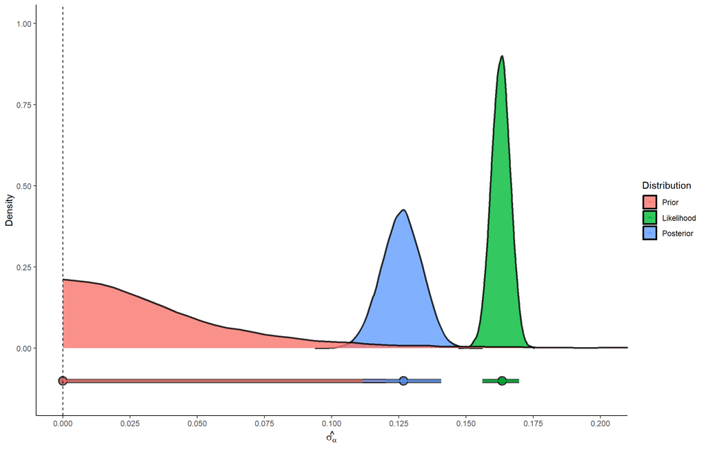

**NOTE**: Posterior, (maximum) likelihood, and prior distributions of the estimated normalized intercept dispersion parameter ($\hat{\sigma_\alpha}$). Posterior/likelihood/prior samples = 40,005; prior is not necessarily correctly visualized due to finite samples. The dashed black line indicates an intercept dispersion of zero. The geometric below the distributions indicate the posterior mode (circle) and the 95% HDCI (thick bar). Results derived from synthetic data generated by OpenAI’s (2024a) gpt-4o-mini using vignettes and questions created by Aarøe and Petersen (2014) and Petersen et al. (2012), as well as data by the IPUMS (Ruggles et al. 2024) and ANES (2021).

Table 10.26: 13-Number Summary of the Dispersion of the Deservingness & Welfare Support ML-BGLM

| Percentile | Posterior | Likelihood |
| --- | --- | --- |
| 0% | 0.187 | 0.163 |
| 0.1% | 0.191 | 0.166 |
| 1% | 0.194 | 0.168 |
| 5% | 0.197 | 0.170 |
| 10% | 0.199 | 0.170 |
| 25% | 0.201 | 0.172 |
| 50% | 0.204 | 0.173 |
| 75% | 0.207 | 0.175 |
| 90% | 0.210 | 0.176 |
| 95% | 0.212 | 0.177 |
| 99% | 0.216 | 0.178 |
| 99.9% | 0.219 | 0.180 |
| 100% | 0.224 | 0.183 |

**NOTE**: Posterior and (maximum) likelihood distributions of the estimated normalized dispersion parameter ($\hat{\sigma}$), estimated with NUTS MCMC (Hoffman and Gelman 2014) and REML-based non-parametric bootstrap (Efron and Tibshirani 1994), respectively. Posterior/likelihood samples = 40,005. Mean = .204 and .173, respectively. IQR = .006 and .003, respectively. Skewness = .125 and -.037, respectively. Kurtosis = .071 and .030, respectively. Results derived from synthetic data generated by OpenAI’s (2024a) gpt-4o-mini using vignettes and questions created by Aarøe and Petersen (2014) and Petersen et al. (2012), as well as data by the IPUMS (Ruggles et al. 2024) and ANES (2021).

Figure 10.30: Dispersion of the Deservingness & Welfare Support ML-BGLM

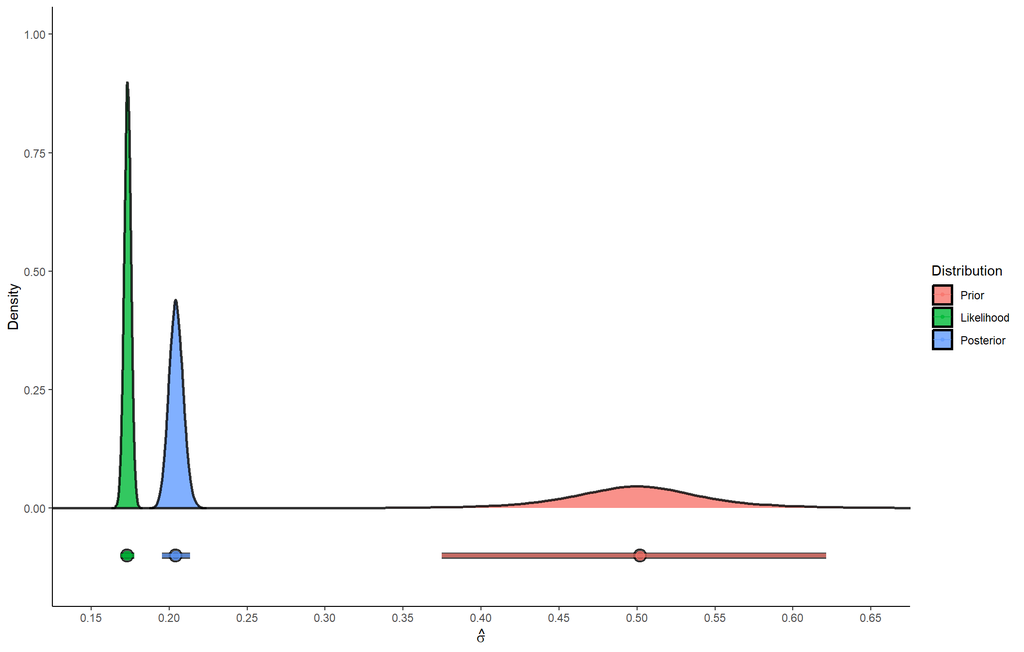

**NOTE**: Posterior, (maximum) likelihood, and prior distributions of the estimated normalized dispersion parameter ($\hat{\sigma}$). Posterior/likelihood/prior samples = 40,005; prior is not necessarily correctly visualized due to finite samples. The geometric below the distributions indicate the posterior mode (circle) and the 95% HDCI (thick bar). Results derived from synthetic data generated by OpenAI’s (2024a) gpt-4o-mini using vignettes and questions created by Aarøe and Petersen (2014) and Petersen et al. (2012), as well as data by the IPUMS (Ruggles et al. 2024) and ANES (2021).

Table 10.27: 13-Number Summary of the Degrees of Freedom of the Deservingness & Welfare Support ML-BGLM

| Percentile | Posterior |
| --- | --- |
| 0% | 134 |
| 0.1% | 574 |
| 1% | 1,170 |
| 5% | 1,532 |
| 10% | 1,650 |
| 25% | 1,795 |
| 50% | 1,899 |
| 75% | 1,963 |
| 90% | 1,997 |
| 95% | 2,007 |
| 99% | 2,016 |
| 99.9% | 2,018 |
| 100% | 2,018 |

**NOTE**: Posterior distribution of the estimated model degrees of freedom ($\hat{\nu}$), estimated with NUTS MCMC (Hoffman and Gelman 2014). Posterior samples = 40,005. Mean = 1849.486. IQR = 168.036. Skewness = -2.703. Results derived from synthetic data generated by OpenAI’s (2024a) gpt-4o-mini using vignettes and questions created by Aarøe and Petersen (2014) and Petersen et al. (2012), as well as data by the IPUMS (Ruggles et al. 2024) and ANES (2021).

Figure 10.31: Degrees of Freedom of the Deservingness & Welfare Support ML-BGLM

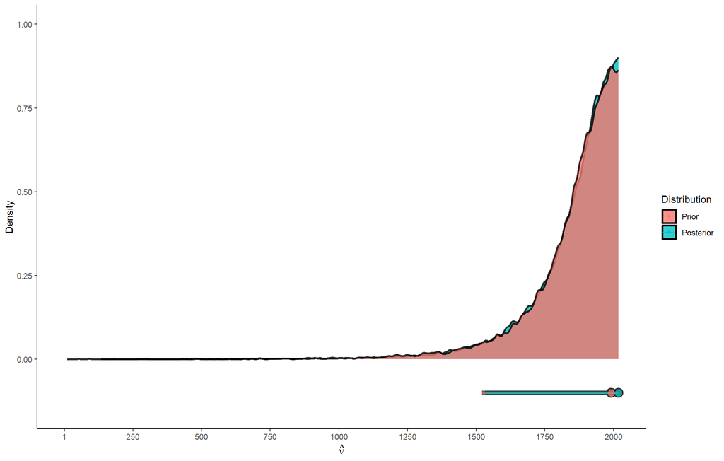

**NOTE**: Posterior and prior distributions of the estimated model degrees of freedom ($\hat{\nu}$). Posterior/prior samples = 40,005; prior is not necessarily correctly visualized due to finite samples. The geometric below the distributions indicate the posterior mode (circle) and the 95% HDCI (thick bar). Results derived from synthetic data generated by OpenAI’s (2024a) gpt-4o-mini using vignettes and questions created by Aarøe and Petersen (2014) and Petersen et al. (2012), as well as data by the IPUMS (Ruggles et al. 2024) and ANES (2021).